# Homework 4

陈旭鹏

2018/4/29

# 1

```r
mp <- matrix(c(5,2,2,2),2,2,byrow=T)
eigen(mp)
```

```
## eigen() decomposition
## $values
## [1] 6 1
##
## $vectors
##            [,1]       [,2]
## [1,] -0.8944272  0.4472136
## [2,] -0.4472136 -0.8944272
```

$$\text{The eigenvalue-eigenvector pairs are } \lambda_1 =6, e_1 = [\frac{2}{\sqrt5},\frac{1}{\sqrt5}]; \lambda_2 =1, e_2 = [-\frac{1}{\sqrt5},\frac{2}{\sqrt5}].\\
\text{Therefore, the principle componenets become: }\\
Y_1 = e_1^T X = \frac{2}{\sqrt5}X_1 +\frac{1}{\sqrt5}X_2\\
Y_1 = e_2^T X = -\frac{1}{\sqrt5}X_1 +\frac{2}{\sqrt5}X_2\\
\text{The total population variance explained by first principal component is:}\\
\frac{var(Y_1)}{var(Y_1)+var(Y_2)} = \frac{\lambda_1}{\lambda_1+\lambda_2} = \frac{6}{1+6} \approx 85.71\%$$

# 2

## a

```r
cov2cor(mp)
```

```
##           [,1]      [,2]
## [1,] 1.0000000 0.6324555
## [2,] 0.6324555 1.0000000
```

$$\text{The correlation matrix } \rho = \left[
\begin{matrix}
1 & \sqrt\frac{2}{5} \\
\sqrt\frac{2}{5}&1
\end{matrix}\right]\\
\text{The eigenvalue-eigenvector pairs are }\\
\lambda_1
= \frac{5+\sqrt {10}}{5}, \ e_1=\left[
\begin{matrix}
\frac{1}{\sqrt 2} \\
\frac{1}{\sqrt 2}
\end{matrix}\right]\\
\lambda_1
= \frac{5-\sqrt {10}}{5}, \ e_1=\left[
\begin{matrix}
-\frac{1}{\sqrt 2} \\
\frac{1}{\sqrt 2}
\end{matrix}\right]$$
$$Let \ \mathbf{Z_i} = \frac{\mathbf{X_i}-\mu_i}{\sqrt {\sigma_{ii}}}, i =1,...,p. \text{The principal components become:}\\
Y_1 = e_1^T Z = \frac{1}{\sqrt2}Z_1 +\frac{1}{\sqrt2}Z_2\\
Y_1 = e_2^T Z = -\frac{1}{\sqrt2}Z_1 +\frac{1}{\sqrt2}Z_2\\
\text{The total population variance explained by first principal component is:}\\
\frac{var(Y_1)}{var(Y_1)+var(Y_2)} = \frac{\lambda_1}{\lambda_1+\lambda_2} = \frac{5+\sqrt{10}}{10} \approx 81.6\%$$

## b

The principal components of Z obtained from the eigenvectors of the correlation matrix ρ of X is different from those calculated from covariance matrix $\Sigma$. Because the eigen pairs derived from $\Sigma$, in general not the same as the ones derived from $\rho$

## c

THe correlations between $Y_j$ and $Z_i$ are:
$$\rho_{Y_1,Z_1} = e_{11}\sqrt {\lambda_1} = \frac{1}{\sqrt2}\sqrt \frac{5+\sqrt {10}}{5} \approx0.903 \\
\rho_{Y_1,Z_2} = e_{12}\sqrt {\lambda_1} = \frac{1}{\sqrt2}\sqrt \frac{5+\sqrt {10}}{5} \approx0.903 \\
\rho_{Y_2,Z_1} = e_{21}\sqrt {\lambda_2} = - \frac{1}{\sqrt2}\sqrt \frac{5-\sqrt {10}}{5} \approx -0.429$$

# 3

## a

```r
# read the data
setwd('~/Desktop/三春/3多元统计分析/作业/作业4/')
dat<-read.csv("table8.4.csv")
X1<-dat$x1
X2<-dat$x2
X3<-dat$x3
X4<-dat$x4
X5<-dat$x5
covar <- cov(dat)
covar
```

```
##              x1           x2           x3           x4           x5
## x1 4.332695e-04 0.0002756679 1.590265e-04 6.411929e-05 8.896616e-05
## x2 2.756679e-04 0.0004387172 1.799737e-04 1.814512e-04 1.232623e-04
## x3 1.590265e-04 0.0001799737 2.239722e-04 7.341348e-05 6.054612e-05
## x4 6.411929e-05 0.0001814512 7.341348e-05 7.224964e-04 5.082772e-04
## x5 8.896616e-05 0.0001232623 6.054612e-05 5.082772e-04 7.656742e-04
```

```r
eigen(cov(dat))
```

```
## eigen() decomposition
## $values
## [1] 0.0013676780 0.0007011596 0.0002538024 0.0001426026 0.0001188868
##
## $vectors
##           [,1]       [,2]        [,3]       [,4]        [,5]
## [1,] 0.2228228  0.6252260  0.32611218  0.6627590  0.11765952
## [2,] 0.3072900  0.5703900 -0.24959014 -0.4140935 -0.58860803
## [3,] 0.1548103  0.3445049 -0.03763929 -0.4970499  0.78030428
## [4,] 0.6389680 -0.2479475 -0.64249741  0.3088689  0.14845546
## [5,] 0.6509044 -0.3218478  0.64586064 -0.2163758 -0.09371777
```

```r
prcomp(dat)
```

```
## Standard deviations (1, .., p=5):
## [1] 0.03698213 0.02647942 0.01593118 0.01194163 0.01090352
##
## Rotation (n x k) = (5 x 5):
##           PC1        PC2         PC3        PC4         PC5
## x1 -0.2228228  0.6252260 -0.32611218  0.6627590 -0.11765952
## x2 -0.3072900  0.5703900  0.24959014 -0.4140935  0.58860803
## x3 -0.1548103  0.3445049  0.03763929 -0.4970499 -0.78030428
## x4 -0.6389680 -0.2479475  0.64249741  0.3088689 -0.14845546
## x5 -0.6509044 -0.3218478 -0.64586064 -0.2163758  0.09371777
```

```r
summary(prcomp(dat))
```

```
## Importance of components%s:
##                            PC1     PC2     PC3     PC4     PC5
## Standard deviation     0.03698 0.02648 0.01593 0.01194 0.01090
## Proportion of Variance 0.52926 0.27133 0.09822 0.05518 0.04601
## Cumulative Proportion  0.52926 0.80059 0.89881 0.95399 1.00000
```

$$Y_1 = e_1^T X= -0.2228228 X_1 -0.3072900 X_2 -0.1548103 X_3 -0.6389680 X_4 -0.6509044 X_5\\
Y_2 = e_2^T X = 0.6252260 X_1 + 0.5703900 X_2 +0.3445049 X_3 -0.2479475 X_4 -0.3218478 X_5\\
Y_3 = e_3^T X= -0.32611218 X_1 + 0.24959014 X_2 +0.03763929 X_3 +0.64249741 X_4 -0.64586064 X_5\\
Y_4 = e_4^T X= 0.6627590 X_1 -0.4140935X_2 -0.4970499 X_3 +0.3088689 X_4 -0.2163758 X_5\\
Y_5 = e_5^T X=-0.11765952 X_1 +0.58860803 X_2 -0.78030428 X_3 -0.14845546 X_4 +0.09371777 X_5$$
## b From the summary above, the proportion of the total sample variance explained by the rst three principal components is: 89.881%. It means that the first three explain almost all variance.

## c

From 8-33, we have the CI of m $\lambda_i$:
$$[\frac{\hat \lambda_i}{1+z(\alpha/2m)\sqrt{2/n}},\frac{\hat \lambda_i}{1-z(\alpha/2m)\sqrt{2/n}}]$$

```r
z <-qnorm(1-1/6)
cical <-function(lambda){
  c(lambda/(1+z*(1/103)**0.5),lambda/(1-z*(1/103)**0.5))
}
cical(0.0013676780)
```

```
## [1] 0.001248653 0.001511786
```

```r
cical(0.0007011596)
```

```
## [1] 0.0006401396 0.0007750385
```

```r
cical(0.0002538024)
```

```
## [1] 0.0002317147 0.0002805447
```

## d

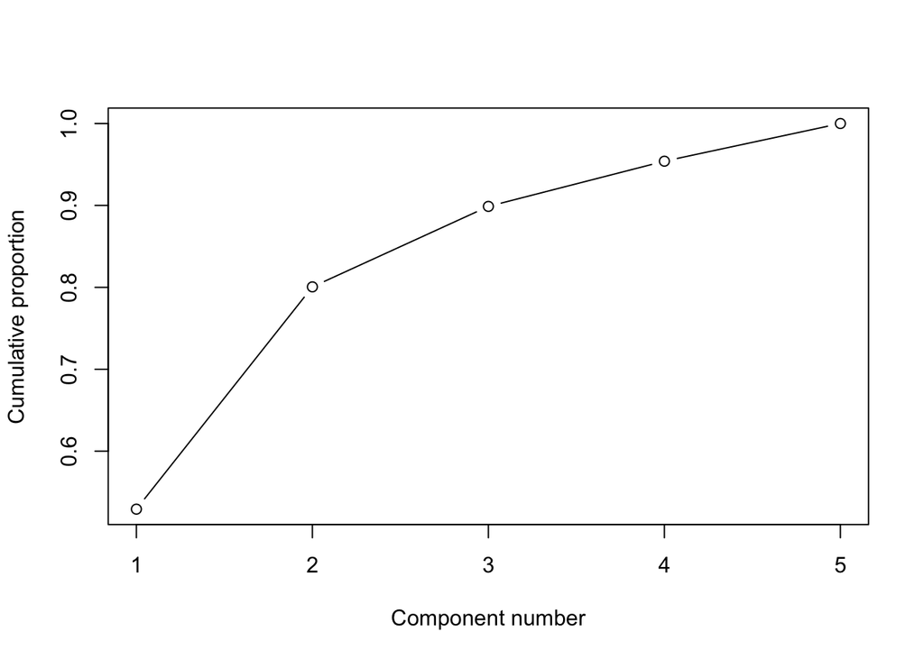

```r
plot(c(0.52926, 0.80059, 0.89881, 0.95399, 1.00000),ylab="Cumulative proportion",xlab="Component number",type='b')
```

From the cumulative proportion plot, it seems that three dimensions’ PC are enough.

# 4

## a

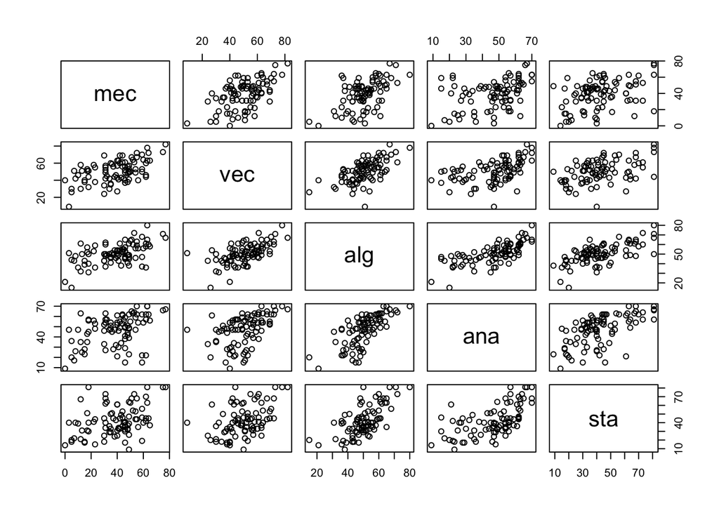

```r
library(bootstrap)
data(scor)
plot(scor)
```

## b

```r
cor(scor)
```

```
##           mec       vec       alg       ana       sta
## mec 1.0000000 0.5534052 0.5467511 0.4093920 0.3890993
## vec 0.5534052 1.0000000 0.6096447 0.4850813 0.4364487
## alg 0.5467511 0.6096447 1.0000000 0.7108059 0.6647357
## ana 0.4093920 0.4850813 0.7108059 1.0000000 0.6071743
## sta 0.3890993 0.4364487 0.6647357 0.6071743 1.0000000
```

## c

```r
prcomp(scor)
```

```
## Standard deviations (1, .., p=5):
## [1] 26.210490 14.216577 10.185642  9.199481  5.670387
##
## Rotation (n x k) = (5 x 5):
##            PC1         PC2        PC3          PC4         PC5
## mec -0.5054457 -0.74874751  0.2997888 -0.296184264 -0.07939388
## vec -0.3683486 -0.20740314 -0.4155900  0.782888173 -0.18887639
## alg -0.3456612  0.07590813 -0.1453182  0.003236339  0.92392015
## ana -0.4511226  0.30088849 -0.5966265 -0.518139724 -0.28552169
## sta -0.5346501  0.54778205  0.6002758  0.175732020 -0.15123239
```

```r
summary(prcomp(scor))
```

```
## Importance of components%s:
##                            PC1     PC2     PC3     PC4     PC5
## Standard deviation     26.2105 14.2166 10.1856 9.19948 5.67039
## Proportion of Variance  0.6191  0.1821  0.0935 0.07627 0.02898
## Cumulative Proportion   0.6191  0.8013  0.8948 0.97102 1.00000
```

$$Y_1 = e_1^T X= -0.5054457 X_1 -0.3683486 X_2 -0.3456612 X_3 -0.4511226 X_4 -0.5346501 X_5\\
Y_2 = e_2^T X = -0.74874751 X_1 -0.20740314 X_2 + 0.07590813 X_3 +0.30088849 X_4 +0.54778205 X_5\\
Y_3 = e_3^T X= 0.2997888 X_1 -0.4155900 X_2 -0.1453182 X_3 -0.5966265 X_4 +0.6002758 X_5\\
Y_4 = e_4^T X= -0.296184264 X_1 + 0.78288817X_2 +0.003236339 X_3 -0.518139724 X_4 +0.175732020 X_5\\
Y_5 = e_5^T X= -0.07939388 X_1 -0.18887639 X_2 +0.92392015 X_3 -0.28552169 X_4 -0.15123239 X_5$$
## d

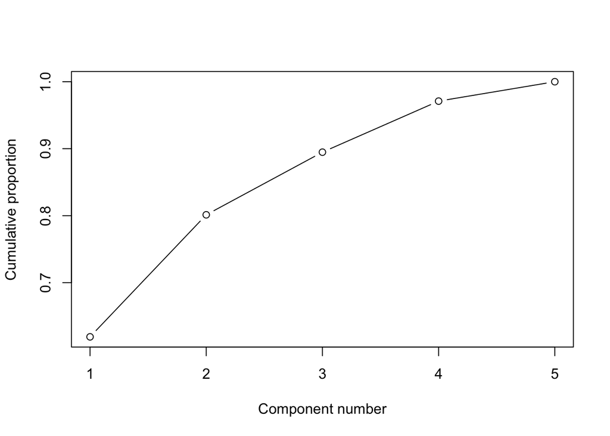

```r
plot(c( 0.6191,0.8013 ,0.8948 ,0.97102, 1.00000),ylab="Cumulative proportion",xlab="Component number",type='b')
```

## e

PC1 may stand for the indicator of scores on all subjects. PC2 has more straightforward mearning: it is related to closed or open rules.

## f

```r
library('ggfortify')
```

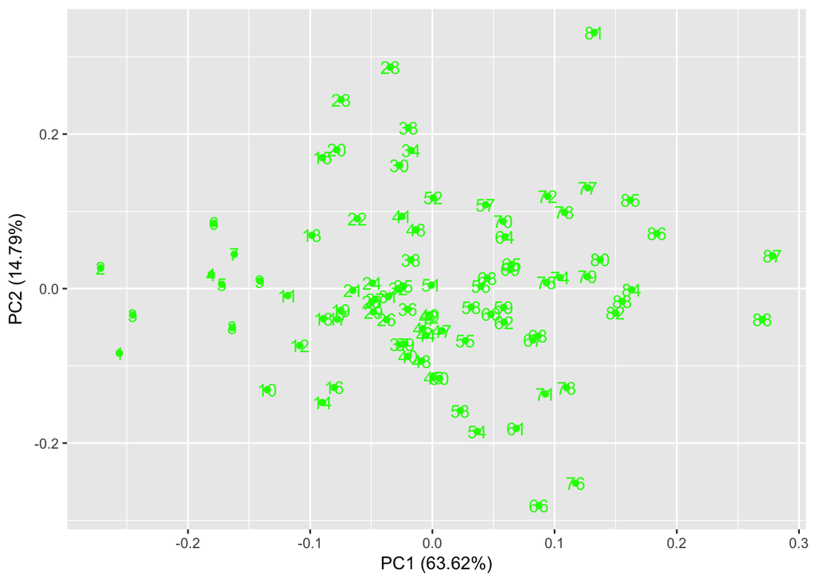

```r
autoplot(prcomp(scor,scale=TRUE),colour='green',label=TRUE)
```

## g

$\chi^2_2(0.05) = 5.99$ I use python to check the outlier:

[output not shown]

And we can find eight outliers: 1,2,23,28,66,76,81,87